# Linear regression coefficients and their variance

Meng Lu lumeng.dev@gmail.com

7/22/2017

(Adapted from https://stats.stackexchange.com/posts/44841/.)

## Linear model

$$\left\{
\begin{array}{l}
\mathbf{y} = \mathbf{X} \mathbf{\beta} + \mathbf{\epsilon} \\
\mathbf{\epsilon} \sim \mathcal{N}(0, \sigma^2 \mathbf{I}),
\end{array}
\right.$$

where

- $\mathbf{y}$ denotes the vector of responses,
- $\mathbf{X}$ is the corresponding design matrix whose columns are the values of the explanatory variables,
- $\mathbf{\beta}$ is the vector of fixed effects parameters, and
- $\mathbf{\epsilon}$ is the vector of random errors.

Assuming the random error $\mathbf{\epsilon}$ is small relative to $\mathbf{X} \mathbf{\beta}$, an estimate of $\beta$ is (see [the wikipedia article][1])

$$\hat{\mathbf{\beta}} = (\mathbf{X}^{\mathrm{T}} \mathbf{X})^{-1} \mathbf{X}^{\mathrm{T}} \mathbf{y}~.$$

Hence
$$\mathop{Var}(\hat{\mathbf{\beta}}) =
(\mathbf{X}^{\prime} \mathbf{X})^{-1} \mathbf{X}^{\prime}
\;\sigma^2 \mathbf{I} \; \mathbf{X} (\mathbf{X}^{\prime} \mathbf{X})^{-1}
= \sigma^2 (\mathbf{X}^{\prime} \mathbf{X})^{-1},$$
Note

- $\mathop{Var}(AX)=A \mathop{Var}(X) A^{\mathrm{T}}$, for a random vector $X$ and a non-random matrix $A$,
- $\mathop{Var}(\mathbf{y}) = \mathop{Var}(\mathbf{X} \beta) + \mathop{Var}(\mathbf{\epsilon}) = \mathop{Var}(\mathbf{\epsilon})$

so that

$$\widehat{\mathop{Var}(\hat{\mathbf{\beta}})} = \widehat{\sigma^2}(\mathbf{X}^{\prime} \mathbf{X})^{-1},$$
where $\widehat{\sigma^2}$ can be obtained by the Mean Square Error (MSE) in the ANOVA table for the linear model `m`. $\widehat{\mathop{Var}(\hat{\mathbf{\beta}})}$ in general will be the [covariance matrix](https://en.wikipedia.org/wiki/Covariance_matrix) whose diagonal elements are the variances of each of $\hat{\beta}_i$, and the off diagonal elements are the other covariances.

## Generate a dataset with $\mathbf{\epsilon} \sim \mathcal{N}(0, 0.3)$

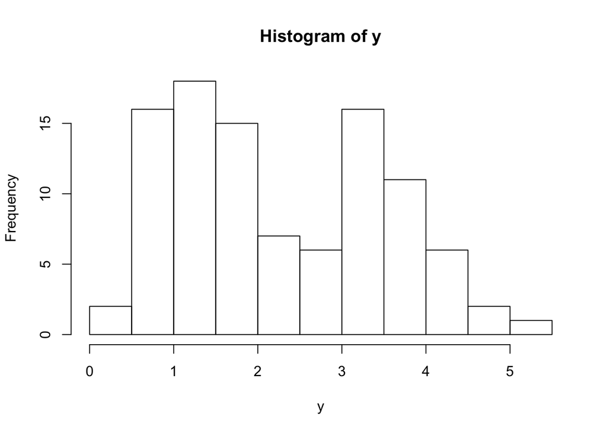

```r
seed <- 9999 #seed
n <- 100     #nb of observations
a <- 1.2       #intercept
b <- 2.3     #slope

set.seed(seed)
epsilon <- rnorm(n, mean=0, sd=sqrt(0.3))
x <- sample(x=c(0, 1), size=n, replace=TRUE)
y <- a + b * x + epsilon

hist(y)
```

## Compute $\hat{\beta}$ and $\widehat{\mathop{Var}(\hat{\beta})}$

### Compute explicitly

Define linear model `m` and check its ANOVA table:

```r
m <- lm(y ~ x)
anova(m)
```

```
## Analysis of Variance Table
##
## Response: y
##           Df  Sum Sq Mean Sq F value    Pr(>F)
## x          1 121.016 121.016  373.73 < 2.2e-16 ***
## Residuals 98  31.733   0.324
## ---
## Signif. codes:  0 '***' 0.001 '**' 0.01 '*' 0.05 '.' 0.1 ' ' 1
```

```r
anova(m)[[3]]
```

```
## [1] 121.0159158   0.3238037
```

Solve for $\hat{\beta}$ and $\widehat{\mathop{Var}(\hat{\beta})}$[^1]:

```r
X <- cbind(1, x)

solve(t(X) %*% X)
```

```
##                         x
##    0.01851852 -0.01851852
## x -0.01851852  0.04025765
```

```r
betaHat <- solve(t(X) %*% X) %*% t(X) %*% y
varHat <- anova(m)[[3]][2]
covar_betaHat <-  varHat * solve(t(X) %*% X)
var_betaHat <- diag(covar_betaHat)
se_betaHat <- sqrt(var_betaHat)

betaHat
```

```
##       [,1]
##   1.259845
## x 2.207219
```

```r
var_betaHat
```

```
##                       x
## 0.005996366 0.013035577
```

```r
se_betaHat
```

```
##                   x
## 0.0774362 0.1141735
```

### Compute using `lm` built-in functions

```r
m <- lm(y ~ x)

summary(m)
```

```
##
## Call:
## lm(formula = y ~ x)
##
## Residuals:
##     Min      1Q  Median      3Q     Max
## -1.2407 -0.3921 -0.0481  0.4080  1.6234
##
## Coefficients:
##             Estimate Std. Error t value Pr(>|t|)
## (Intercept)  1.25984    0.07744   16.27   <2e-16 ***
## x            2.20722    0.11417   19.33   <2e-16 ***
## ---
## Signif. codes:  0 '***' 0.001 '**' 0.01 '*' 0.05 '.' 0.1 ' ' 1
##
## Residual standard error: 0.569 on 98 degrees of freedom
## Multiple R-squared:  0.7923, Adjusted R-squared:  0.7901
## F-statistic: 373.7 on 1 and 98 DF,  p-value: < 2.2e-16
```

Just print the coefficients $\hat{\beta}$ and the standard error of the coefficients $\sqrt{\mathop{VAR}(\hat{\beta})}$

```r
t(m$coef)
```

```
##      (Intercept)        x
## [1,]    1.259845 2.207219
```

or

```r
summary(m)$coefficients[, 2]
```

```
## (Intercept)           x
##   0.0774362   0.1141735
```

### Comparison

- $\hat{\beta}$

```r
m$coef
```

```
## (Intercept)           x
##    1.259845    2.207219
```

```r
betaHat
```

```
##       [,1]
##   1.259845
## x 2.207219
```

- $\widehat{\mathop{Var}(\hat{\beta})}$

```r
summary(m)$coefficients[, 2]
```

```
## (Intercept)           x
##   0.0774362   0.1141735
```

```r
se_betaHat
```

```
##                   x
## 0.0774362 0.1141735
```

## Univariate linear model

When there is a single explanatory variable, the model reduces to
$$y_i = a + bx_i + \epsilon_i, \qquad i = 1, \dotsc, n$$
and
$$\mathbf{X} = \left(
\begin{array}{cc}
1 & x_1 \\
1 & x_2 \\
\vdots & \vdots \\
1 & x_n
\end{array}
\right), \qquad \mathbf{\beta} = \left(
\begin{array}{c}
\beta_0\\\beta_1
\end{array}
\right)$$

so that the covariance matrix is

$$\begin{eqnarray}
\mathop{Cov}(\hat{\beta}) & = & \sigma^2 (\mathbf{X}^{\prime} \mathbf{X})^{-1}\\
& = & \frac{\sigma^2}{n\sum x_i^2 - (\sum x_i)^2}
\left(
\begin{array}{cc}
\sum x_i^2 & -\sum x_i \\
-\sum x_i & n
\end{array}
\right)
\end{eqnarray}$$

The standard error of the estimated slope is

$$SE_{\hat{\beta}_1} = \sqrt{\mathop{Cov}(\hat{\beta})_{22}} = \sqrt{\frac{n \hat{\sigma^2}}{n\sum x_i^2 - (\sum x_i)^2}}~.$$

The standard error of the estimated intercept is

$$SE_{\hat{\beta}_0} = \sqrt{\mathop{Cov}(\hat{\beta})_{11}} = \sqrt{\frac{\sum x_i^2 \hat{\sigma^2}}{n\sum x_i^2 - (\sum x_i)^2}}~.$$

```r
mse <- anova(m)[[3]][2]
se_beta1 <- sqrt(n * mse / (n * sum(x^2) - sum(x)^2))
se_beta0 <- sqrt(sum(x^2) * mse / (n * sum(x^2) - sum(x)^2))
se_beta <- c(se_beta0, se_beta1)
se_beta
```

```
## [1] 0.0774362 0.1141735
```

where `mse`, the Mean Squared Error[^2], is taken from

```r
anova(m)
```

```
## Analysis of Variance Table
##
## Response: y
##           Df  Sum Sq Mean Sq F value    Pr(>F)
## x          1 121.016 121.016  373.73 < 2.2e-16 ***
## Residuals 98  31.733   0.324
## ---
## Signif. codes:  0 '***' 0.001 '**' 0.01 '*' 0.05 '.' 0.1 ' ' 1
```

and used as the estimate $\hat{\sigma^2}$.

With the R built-in functions, they can be read off of:

```r
summary(m)
```

```
##
## Call:
## lm(formula = y ~ x)
##
## Residuals:
##     Min      1Q  Median      3Q     Max
## -1.2407 -0.3921 -0.0481  0.4080  1.6234
##
## Coefficients:
##             Estimate Std. Error t value Pr(>|t|)
## (Intercept)  1.25984    0.07744   16.27   <2e-16 ***
## x            2.20722    0.11417   19.33   <2e-16 ***
## ---
## Signif. codes:  0 '***' 0.001 '**' 0.01 '*' 0.05 '.' 0.1 ' ' 1
##
## Residual standard error: 0.569 on 98 degrees of freedom
## Multiple R-squared:  0.7923, Adjusted R-squared:  0.7901
## F-statistic: 373.7 on 1 and 98 DF,  p-value: < 2.2e-16
```

```r
se_beta_R <- summary(m)$coefficients[,2]
se_beta_R
```

```
## (Intercept)           x
##   0.0774362   0.1141735
```

## References

- http://en.wikipedia.org/wiki/Linear_regression
- https://stats.stackexchange.com/posts/44841/

## Footnotes

[^1]: In R, `solve(m)` gives the inverse of a matrix `m`.
[^2]: In regression analysis, the term ‘mean squared error’ (MSE) is sometimes used to refer to the unbiased estimate of error variance: the sum of squared residuals divided by the number of degrees of freedom.